# 705assign4_guide_r

2024-10-23

# Libraries

```r
library(glmnet) # lasso
library(latex2exp) # math symbols in plots
library(mosaic) # bootstrapping and data manipulation
```

# Data Import

```r
url="https://raw.githubusercontent.com/jlacasa/stat705_fall2024/main/classes/data/prostate.csv"
dd_prostate=read.csv(url)
```

# Data Split

```r
# train and test split
train=filter(dd_prostate,train=="TRUE")
test=filter(dd_prostate,train=="FALSE")
```

# Exploratory Analysis

Exploratory analyses are my preferred first step in any statistics/data analysis project. I’m starting by printing the head of my data to get an idea of variable names and data types, (i.e., whether the data is discrete or continuous).

```r
# first 10 rows of each column
head(train)
```

```
##       lcavol  lweight age      lbph svi       lcp gleason pgg45       lpsa
## 1 -0.5798185 2.769459  50 -1.386294   0 -1.386294       6     0 -0.4307829
## 2 -0.9942523 3.319626  58 -1.386294   0 -1.386294       6     0 -0.1625189
## 3 -0.5108256 2.691243  74 -1.386294   0 -1.386294       7    20 -0.1625189
## 4 -1.2039728 3.282789  58 -1.386294   0 -1.386294       6     0 -0.1625189
## 5  0.7514161 3.432373  62 -1.386294   0 -1.386294       6     0  0.3715636
## 6 -1.0498221 3.228826  50 -1.386294   0 -1.386294       6     0  0.7654678
##   train
## 1  TRUE
## 2  TRUE
## 3  TRUE
## 4  TRUE
## 5  TRUE
## 6  TRUE
```

Next I plotted a histogram of my intended response variable, `lpsa`, to get a rough read on how the data is distributed.

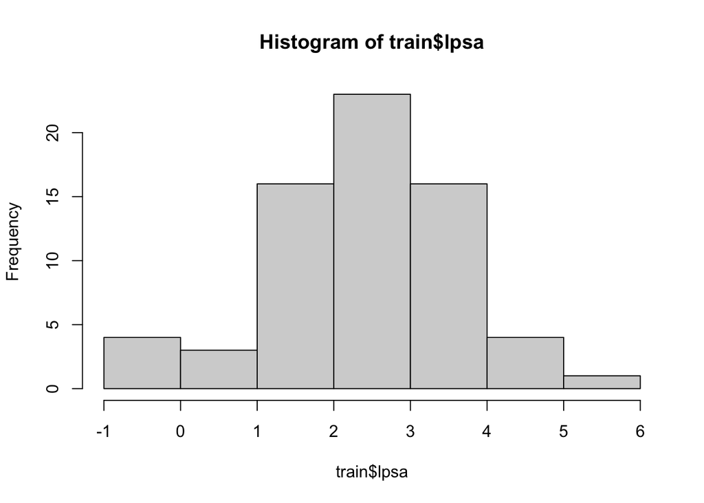

```r
# checking distribution assumptions of response
hist(train$lpsa)
```

Then I’m just plotting my response against various possible predictor variables. `pgg45` and `svi` were avoided because of high incidence of $0$ values, and `lbph` was honestly just missed in the moment.

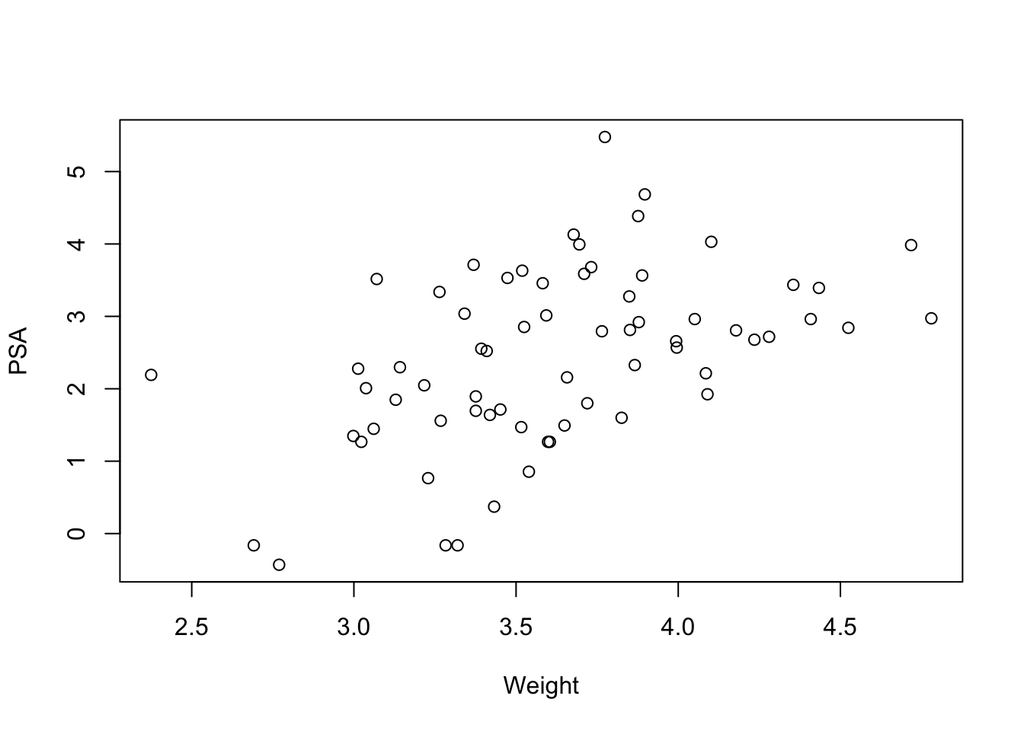

```r
# plotting variables against response (graphical variable selection)
plot(train$lweight,train$lpsa,xlab="Weight",ylab="PSA")
```

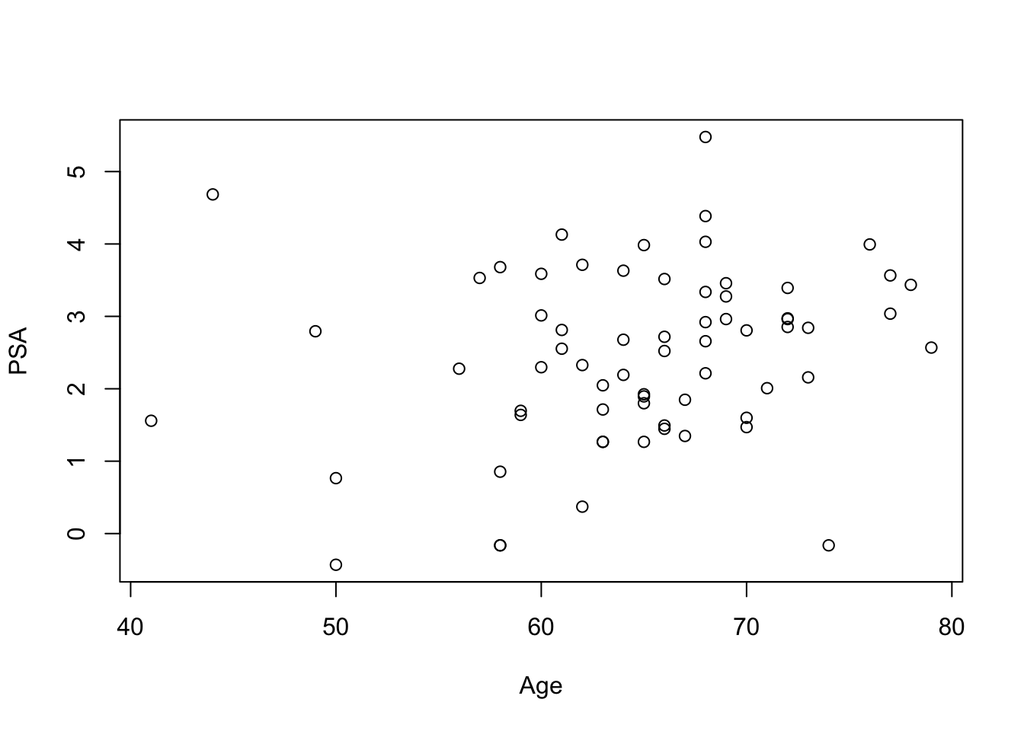

```r
plot(train$age,train$lpsa,xlab="Age",ylab="PSA")
```

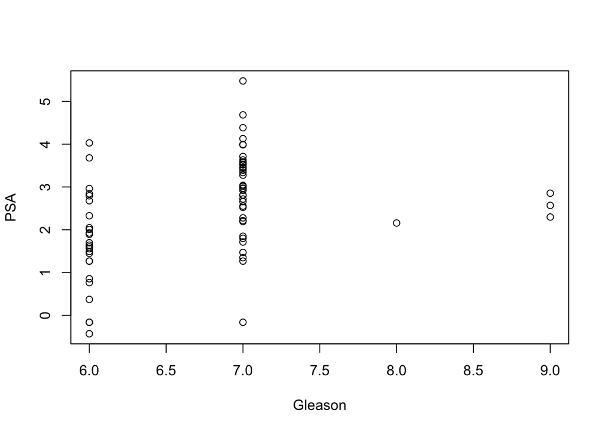

```r
plot(train$gleason,train$lpsa,xlab="Gleason",ylab="PSA")
```

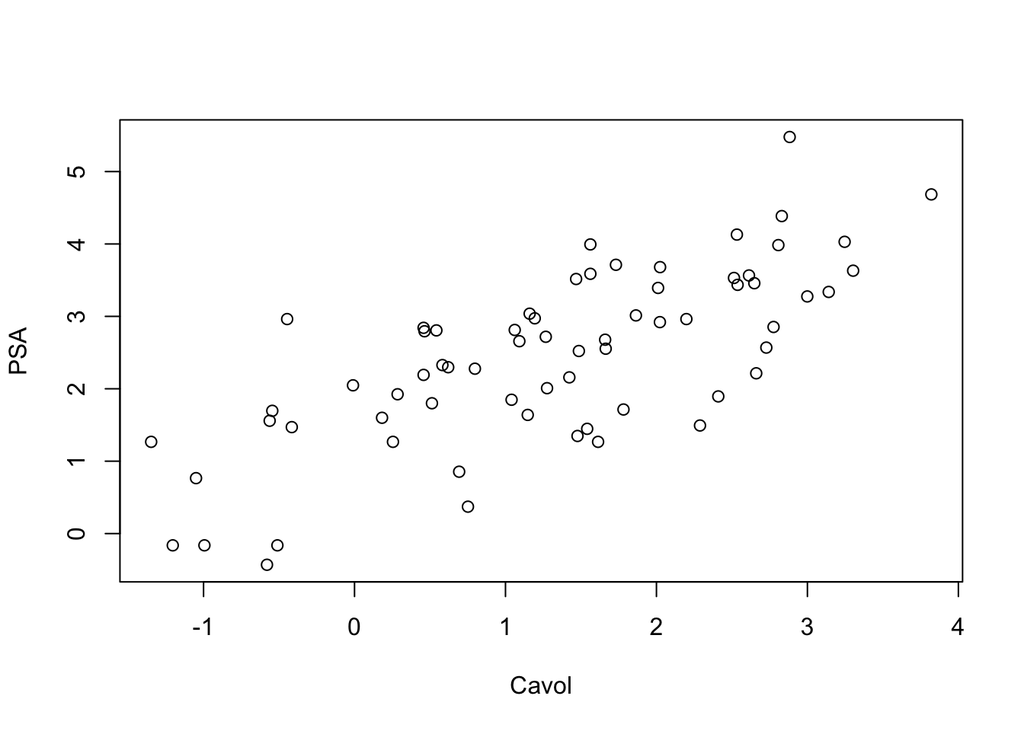

```r
plot(train$lcavol,train$lpsa,xlab="Cavol",ylab="PSA")
```

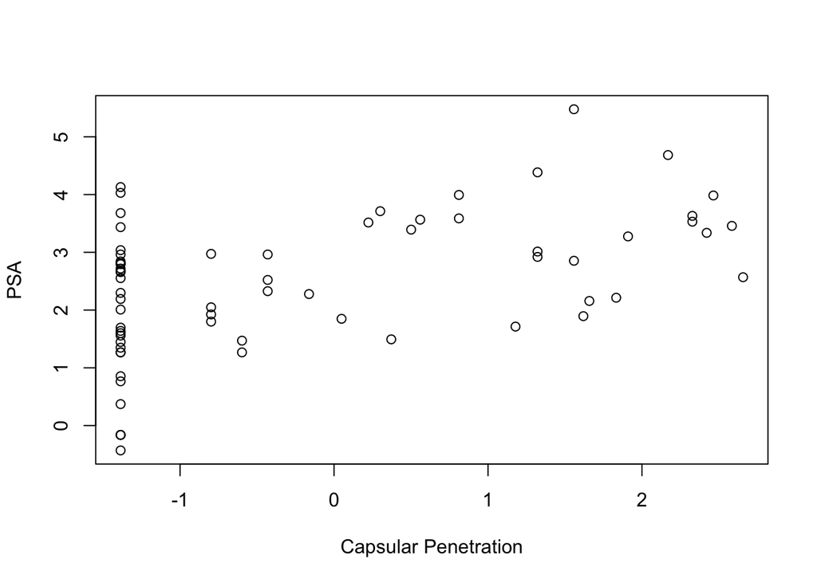

```r
plot(train$lcp,train$lpsa,xlab="Capsular Penetration",ylab="PSA")
```

# LASSO

I chose to pair my graphical selection with LASSO as a form of “fact check” for my gut feeling.

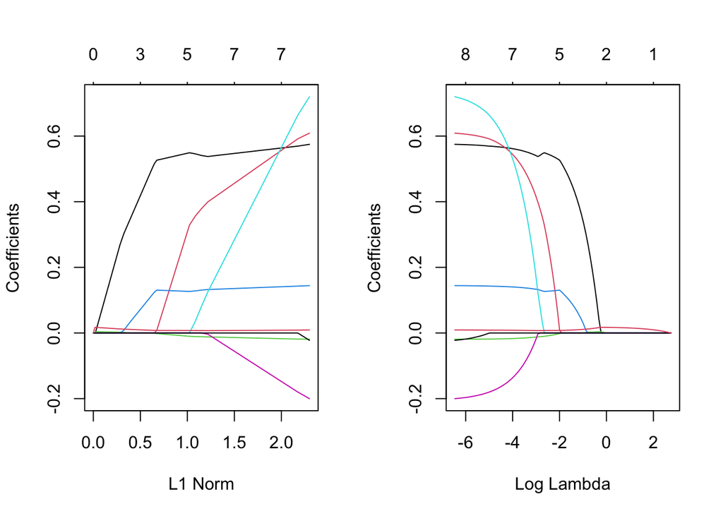

```r
# its so much easier to do this in R its not even funny
y=train$lpsa
X=model.matrix(lpsa~.,train)[,-1]
fit_lasso=glmnet(X,y,family=c("gaussian"),alpha=1,standardize=FALSE)
par(mfrow=c(1,2))
plot(fit_lasso)
plot(fit_lasso,xvar="lambda",label=TRUE)
```

```r
coef(fit_lasso)[,100]
```

```
##  (Intercept)       lcavol      lweight          age         lbph          svi
##  0.404484828  0.574913700  0.608939008 -0.018893525  0.144364248  0.720031225
##          lcp      gleason        pgg45    trainTRUE
## -0.200094947 -0.022334689  0.009284446  0.000000000
```

Overall I would only exclude `lcp`, everything else I would still consider viable, if for no other reason than to put the same burden of fact checking onto LASSO.

# Model Proposals

I investigated two possible models, for simplicity sake I *capped* my models at $3$ predictors, rather than considering it a minimum. Both models will include `lweight` and `age`, while the difference between each model will be the inclusion of `gleason` versus `lcavol`.

My goal was to make a simple comparison and get a high performing model with *good calibration* without muddying up the interpretation with too many variables.

**Model 1**

$$y_{ij}=\beta_0+\beta_1w+\beta_2a+\beta_3t_j+\epsilon_{ij}$$

$$\epsilon_{ij} \sim
N(0,\sigma^2)$$

**Model 2**

$$y_{i}=\beta_0+\beta_1w+\beta_2a+\beta_3c+\epsilon_{i}$$

$$\epsilon_{i} \sim
N(0,\sigma^2)$$

# Model Fitting

```r
m1=lm(lpsa~lweight+age+as.factor(gleason),data=train)
m2=lm(lpsa~lweight+age+lcavol,data=train)
```

```r
summary(m1)
```

```
##
## Call:
## lm(formula = lpsa ~ lweight + age + as.factor(gleason), data = train)
##
## Residuals:
##      Min       1Q   Median       3Q      Max
## -1.81889 -0.55429 -0.03658  0.63347  2.40783
##
## Coefficients:
##                     Estimate Std. Error t value Pr(>|t|)
## (Intercept)         -1.80149    1.16762  -1.543   0.1280
## lweight              1.22428    0.25293   4.840 9.20e-06 ***
## age                 -0.01464    0.01739  -0.841   0.4034
## as.factor(gleason)7  1.24613    0.25233   4.938 6.44e-06 ***
## as.factor(gleason)8  0.55016    0.96231   0.572   0.5696
## as.factor(gleason)9  1.05302    0.58652   1.795   0.0775 .
## ---
## Signif. codes:  0 '***' 0.001 '**' 0.01 '*' 0.05 '.' 0.1 ' ' 1
##
## Residual standard error: 0.9232 on 61 degrees of freedom
## Multiple R-squared:   0.46,  Adjusted R-squared:  0.4157
## F-statistic: 10.39 on 5 and 61 DF,  p-value: 3.061e-07
```

```r
summary(m2)
```

```
##
## Call:
## lm(formula = lpsa ~ lweight + age + lcavol, data = train)
##
## Residuals:
##      Min       1Q   Median       3Q      Max
## -1.59665 -0.43183  0.00286  0.49425  1.93751
##
## Coefficients:
##              Estimate Std. Error t value Pr(>|t|)
## (Intercept) -0.598680   0.984032  -0.608 0.545113
## lweight      0.775401   0.213917   3.625 0.000579 ***
## age         -0.009274   0.013529  -0.686 0.495543
## lcavol       0.639376   0.081225   7.872 5.98e-11 ***
## ---
## Signif. codes:  0 '***' 0.001 '**' 0.01 '*' 0.05 '.' 0.1 ' ' 1
##
## Residual standard error: 0.7645 on 63 degrees of freedom
## Multiple R-squared:  0.6176, Adjusted R-squared:  0.5994
## F-statistic: 33.92 on 3 and 63 DF,  p-value: 3.591e-13
```

# Model Evaluation

### Graphical Checks

These graphical evaluations are just to filter out anything egregious, nothing beyond that.

#### Model 1

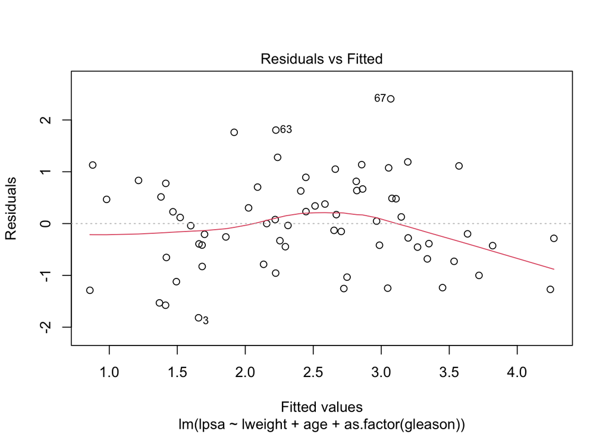

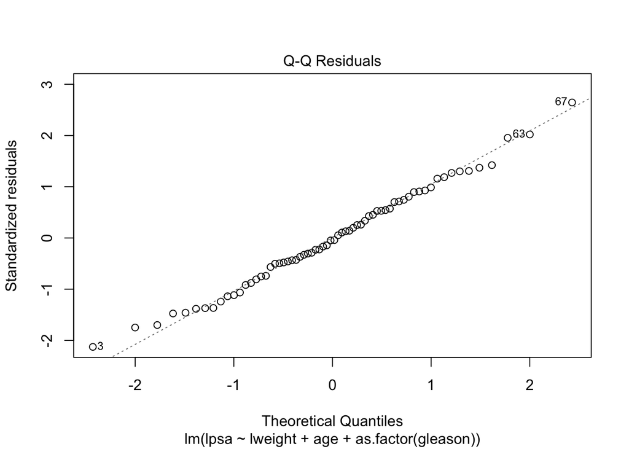

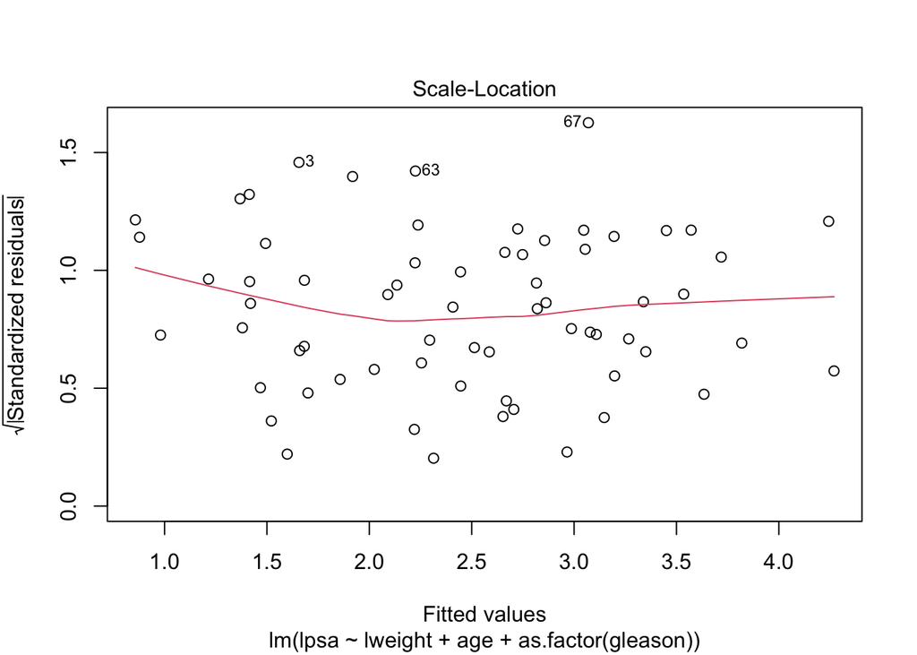

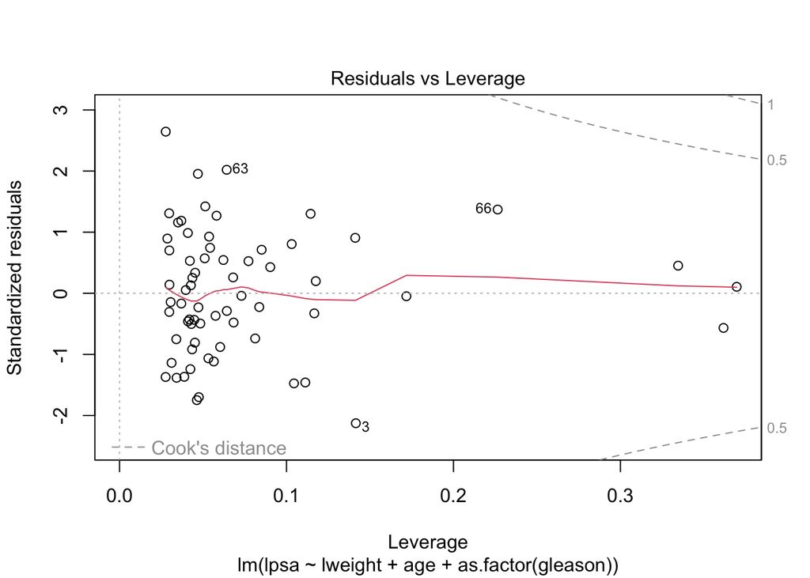

```r
# model check plotting
# it actually is this easy
plot(m1)
```

#### Model 2

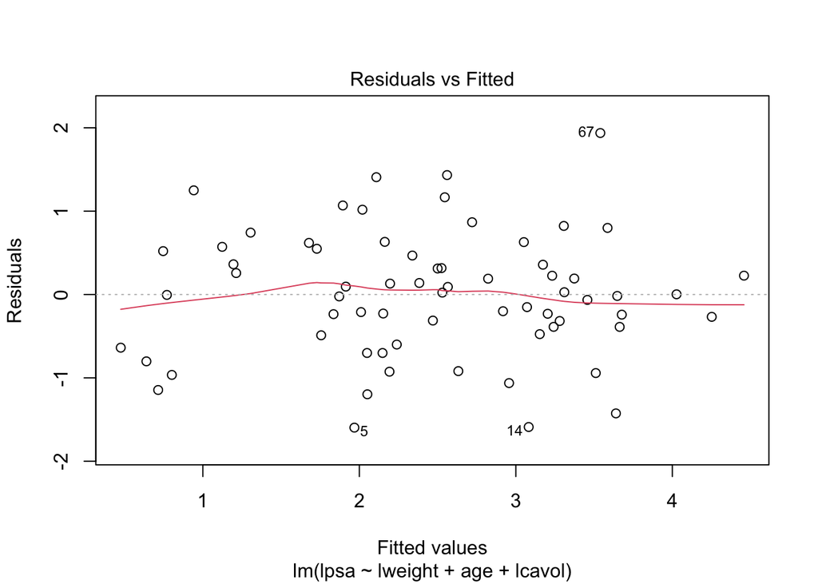

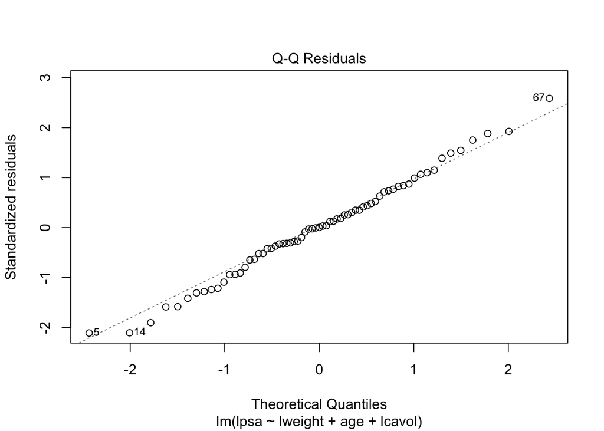

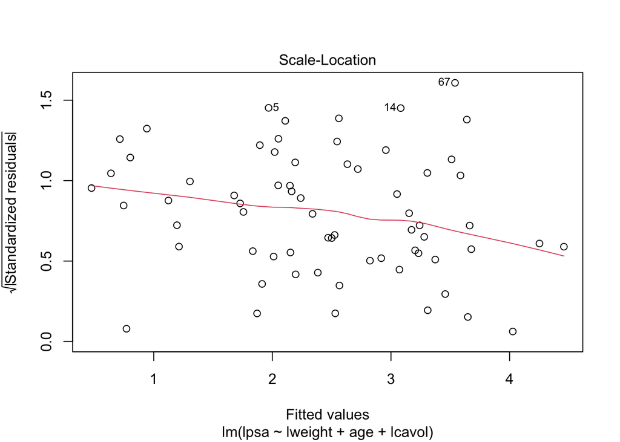

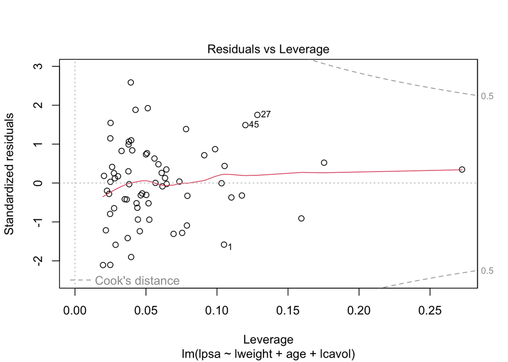

```r
plot(m2)
```

### Predictive Checks

I checked Mean Squared Error, Root Mean Squared Error, and coverage using the testing data.

```r
# predict from test set
E.y.hat=predict(m1,newdata=test)
y=test$lpsa

mean((y-E.y.hat)^2) # mean squared error
```

```
## [1] 0.9167181
```

```r
mean((y-E.y.hat)^2)^0.5 # root mean squared error
```

```
## [1] 0.9574539
```

```r
# prediction intervals
li=predict(m1,newdata=test,interval="prediction",level=0.95)[,2]
ui=predict(m1,newdata=test,interval="prediction",level=0.95)[,3]

# checking if our data is within our prediction intervals
cover=ifelse(y>li,1,0)*ifelse(y<ui,1,0)
mean(cover)
```

```
## [1] 0.9333333
```

```r
E.y.hat=predict(m2,newdata=test)

mean((y-E.y.hat)^2) # mean squared error
```

```
## [1] 0.4800778
```

```r
mean((y-E.y.hat)^2)^0.5 # root mean squared error
```

```
## [1] 0.6928765
```

```r
# prediction intervals
li=predict(m2,newdata=test,interval="prediction",level=0.95)[,2]
ui=predict(m2,newdata=test,interval="prediction",level=0.95)[,3]

# checking if our data is within our prediction intervals
cover=ifelse(y>li,1,0)*ifelse(y<ui,1,0)
mean(cover)
```

```
## [1] 0.9666667
```

### Uncertainty Estimates

I concluded with bootstrapping uncertainty estimates for $\beta_0$, $\beta_1$, and $\beta_2$ for each model. I chose to show just those three since they’re the **shared** variables between the two models, and included both models since the difference between them is not severe enough to consider one unusable.

```r
set.seed(1)
# so much faster to bootstrap this way
m1_boot=do(1000)*coef(lm(lpsa~lweight+age+as.factor(gleason),data=resample(train)))
m2_boot=do(1000)*coef(lm(lpsa~lweight+age+lcavol,data=resample(train)))
```

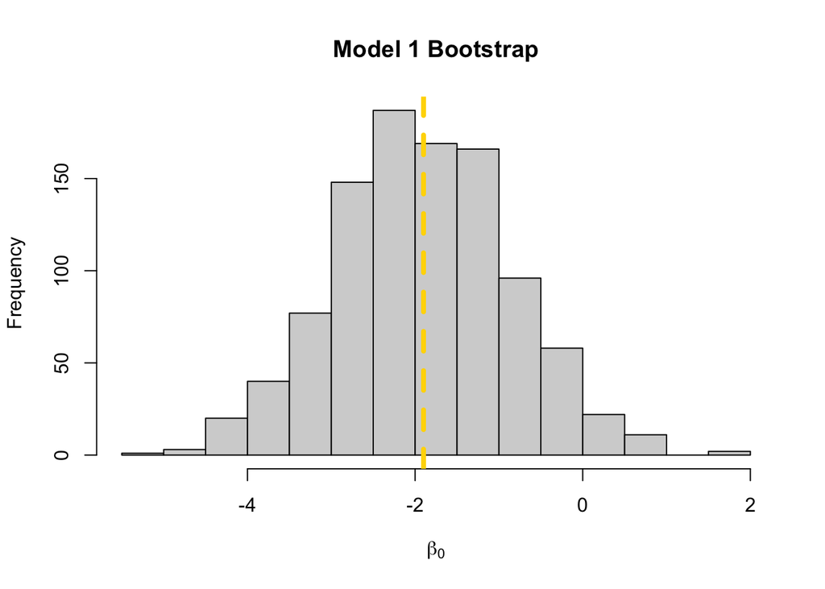

```r
hist(m1_boot$Intercept,xlab=TeX("$\\beta_0$"),main="Model 1 Bootstrap")
abline(v=mean(m1_boot$Intercept),lwd=4,lty=2,col="gold")
```

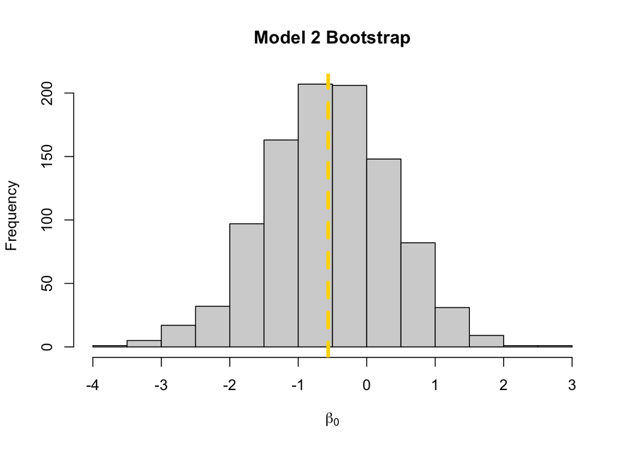

```r
hist(m2_boot$Intercept,xlab=TeX("$\\beta_0$"),main="Model 2 Bootstrap")
abline(v=mean(m2_boot$Intercept),lwd=4,lty=2,col="gold")
```

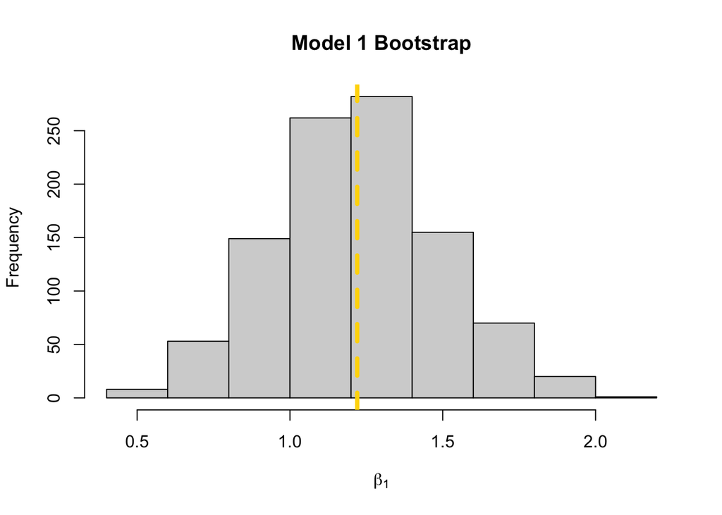

```r
hist(m1_boot$lweight,xlab=TeX("$\\beta_1$"),main="Model 1 Bootstrap")
abline(v=mean(m1_boot$lweight),lwd=4,lty=2,col="gold")
```

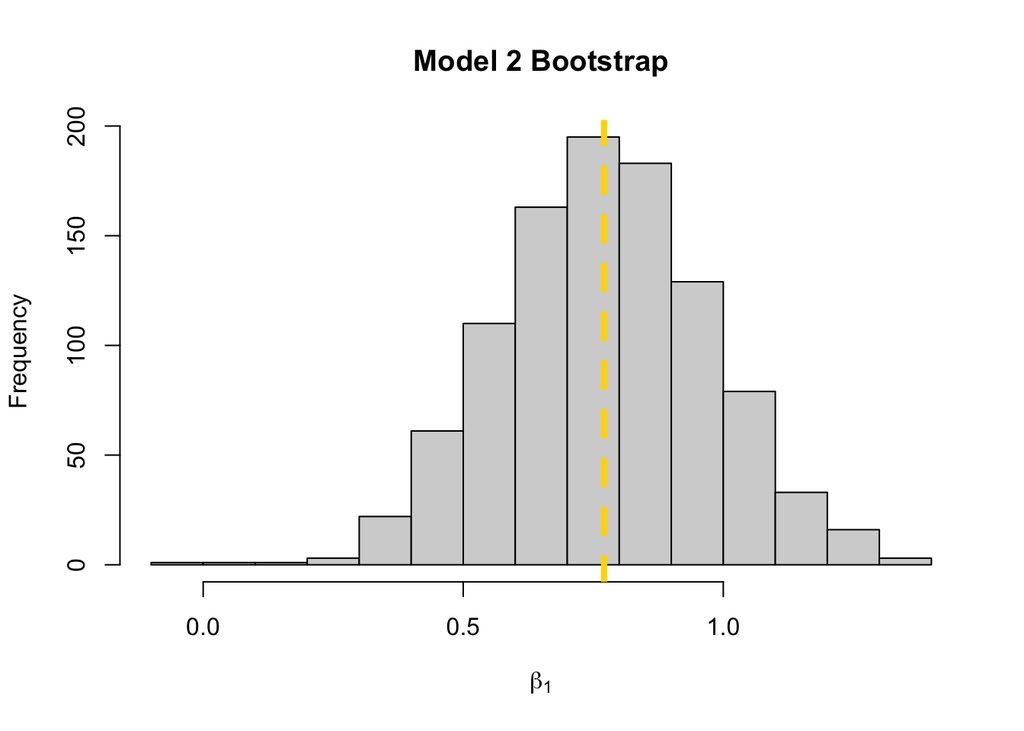

```r
hist(m2_boot$lweight,xlab=TeX("$\\beta_1$"),main="Model 2 Bootstrap")
abline(v=mean(m2_boot$lweight),lwd=4,lty=2,col="gold")
```

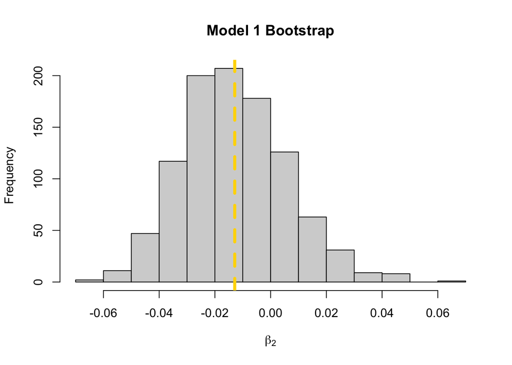

```r
hist(m1_boot$age,xlab=TeX("$\\beta_2$"),main="Model 1 Bootstrap")
abline(v=mean(m1_boot$age),lwd=4,lty=2,col="gold")
```

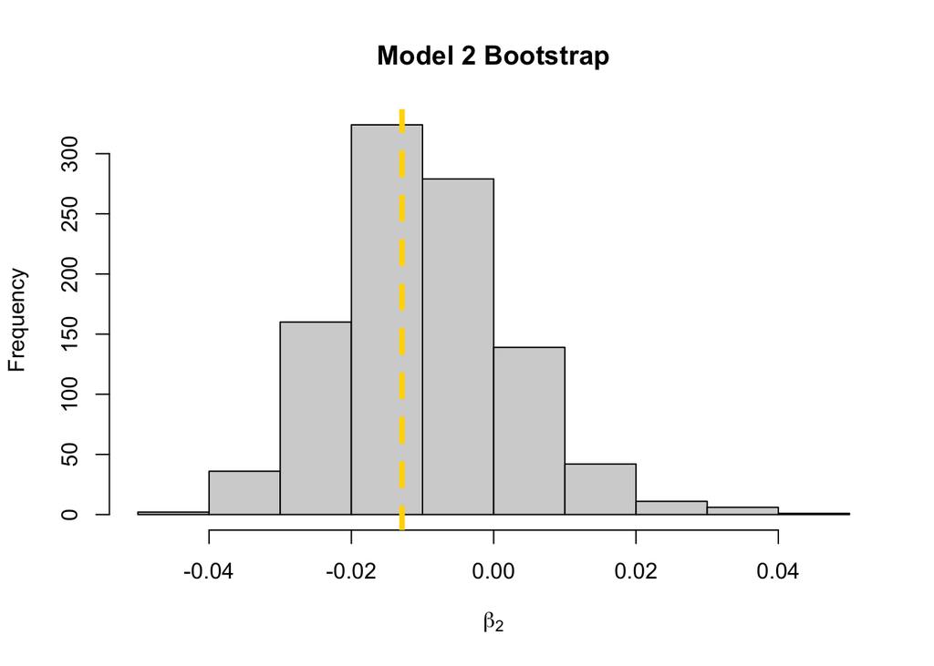

```r
hist(m2_boot$age,xlab=TeX("$\\beta_2$"),main="Model 2 Bootstrap")
abline(v=mean(m1_boot$age),lwd=4,lty=2,col="gold")
```